# Canada’s Economic Pulse

Are Canadians keeping up? Wages, Housing, and Employment (2014–2024)

Muhammad

2026-04-21

> **Data sources:** Statistics Canada open data (tables 14-10-0023-01, 18-10-0005-01, 14-10-0064-01)  
> **Before knitting:** make sure you’ve run `data/fetch_data.R` and `data/clean_data.R` first.

## Setup

```r
library(dplyr)
library(tidyr)
library(readr)
library(ggplot2)
library(scales)
library(forcats)

PROC <- "processed/"

wages_vs_cpi <- read_csv(paste0(PROC, "wages_vs_cpi.csv"),   show_col_types = FALSE)
wages_annual <- read_csv(paste0(PROC, "wages_annual.csv"),   show_col_types = FALSE)
cpi_annual   <- read_csv(paste0(PROC, "cpi_annual.csv"),     show_col_types = FALSE)
emp_annual   <- read_csv(paste0(PROC, "employment_annual.csv"), show_col_types = FALSE)
emp_monthly  <- read_csv(paste0(PROC, "employment_monthly.csv"), show_col_types = FALSE)

# Shared theme for all charts
theme_pulse <- function() {
  theme_minimal(base_size = 13) +
    theme(
      plot.title    = element_text(face = "bold", size = 14),
      plot.subtitle = element_text(colour = "grey40", size = 11),
      legend.position = "bottom",
      panel.grid.minor = element_blank()
    )
}

message("Datasets loaded ✓")
message(sprintf("  wages_vs_cpi:  %d x %d", nrow(wages_vs_cpi), ncol(wages_vs_cpi)))
message(sprintf("  wages_annual:  %d x %d", nrow(wages_annual),  ncol(wages_annual)))
message(sprintf("  cpi_annual:    %d x %d", nrow(cpi_annual),    ncol(cpi_annual)))
message(sprintf("  emp_annual:    %d x %d", nrow(emp_annual),    ncol(emp_annual)))
```

## 1. Quick Data Inspection

```r
wages_vs_cpi %>% head(10)
```

```
## # A tibble: 10 × 8
##     year geo      avg_hourly_wage cpi_all_items cpi_shelter wage_index cpi_index
##    <dbl> <chr>              <dbl>         <dbl>       <dbl>      <dbl>     <dbl>
##  1  2014 Alberta             29.1          132.        162.        100       100
##  2  2014 British…            25.0          119.        114.        100       100
##  3  2014 Canada              25.2          125.        132.        100       100
##  4  2014 Manitoba            23.0          125.        135.        100       100
##  5  2014 New Bru…            21.4          125.        129.        100       100
##  6  2014 Newfoun…            25.6          128.        150         100       100
##  7  2014 Nova Sc…            22.4          129.        141.        100       100
##  8  2014 Ontario             25.4          126.        132.        100       100
##  9  2014 Prince …            20.9          130.        135.        100       100
## 10  2014 Quebec              23.7          123.        128.        100       100
## # ℹ 1 more variable: shelter_index <dbl>
```

```r
wages_annual %>%
  group_by(year) %>%
  summarise(
    min  = min(avg_hourly_wage,  na.rm = TRUE),
    mean = mean(avg_hourly_wage, na.rm = TRUE),
    max  = max(avg_hourly_wage,  na.rm = TRUE),
    .groups = "drop"
  ) %>%
  mutate(across(min:max, ~ round(.x, 2)))
```

```
## # A tibble: 11 × 4
##     year   min  mean   max
##    <dbl> <dbl> <dbl> <dbl>
##  1  2014  20.9  24.3  29.1
##  2  2015  21.4  24.8  29.9
##  3  2016  21.7  25.3  30.4
##  4  2017  22.3  25.7  30.8
##  5  2018  22.5  26.3  31.4
##  6  2019  22.9  26.8  32
##  7  2020  24.3  28.4  33.5
##  8  2021  25.3  28.9  33.2
##  9  2022  26.8  30.2  33.6
## 10  2023  27.9  31.6  35.0
## 11  2024  29.6  33.2  36.6
```

## 2. Chart 1 — Wages vs. Shelter CPI (indexed to 2014 = 100)

> **The core story:** If shelter costs rise faster than wages, Canadians are falling behind on housing affordability.

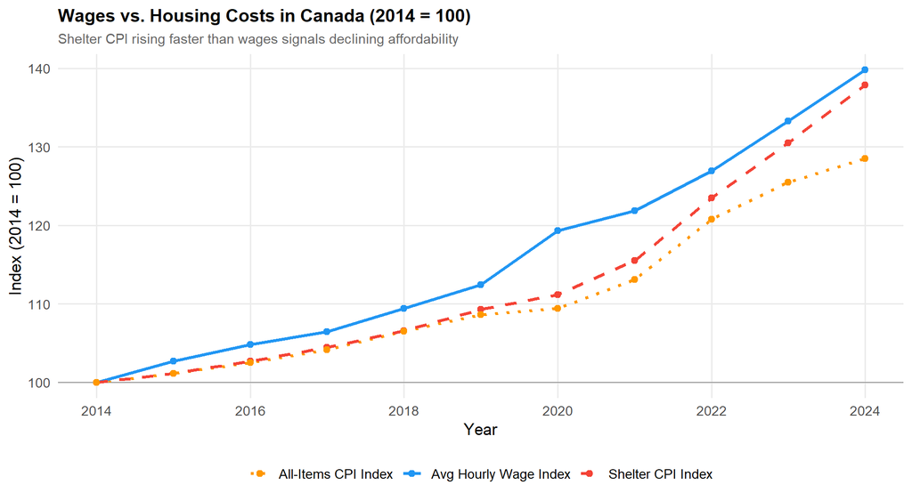

```r
national <- wages_vs_cpi %>% filter(geo == "Canada")

# Reshape to long format — the ggplot2 way
national_long <- national %>%
  select(year, wage_index, shelter_index, cpi_index) %>%
  pivot_longer(
    cols      = c(wage_index, shelter_index, cpi_index),
    names_to  = "series",
    values_to = "index_value"
  ) %>%
  mutate(series = recode(series,
    wage_index    = "Avg Hourly Wage Index",
    shelter_index = "Shelter CPI Index",
    cpi_index     = "All-Items CPI Index"
  ))

ggplot(national_long, aes(x = year, y = index_value, colour = series, linetype = series)) +
  geom_hline(yintercept = 100, colour = "grey60", linewidth = 0.4) +
  geom_line(linewidth = 1.2) +
  geom_point(size = 2) +
  scale_colour_manual(values = c(
    "Avg Hourly Wage Index" = "#2196F3",
    "Shelter CPI Index"    = "#F44336",
    "All-Items CPI Index"  = "#FF9800"
  )) +
  scale_linetype_manual(values = c(
    "Avg Hourly Wage Index" = "solid",
    "Shelter CPI Index"    = "dashed",
    "All-Items CPI Index"  = "dotted"
  )) +
  scale_x_continuous(breaks = seq(2014, 2024, 2)) +
  labs(
    title    = "Wages vs. Housing Costs in Canada (2014 = 100)",
    subtitle = "Shelter CPI rising faster than wages signals declining affordability",
    x        = "Year",
    y        = "Index (2014 = 100)",
    colour   = NULL,
    linetype = NULL
  ) +
  theme_pulse()
```

```r
row_2024 <- national %>% filter(year == 2024)
gap      <- row_2024$shelter_index - row_2024$wage_index

cat(sprintf(
  "In 2024 (indexed to 2014 = 100):\n  Wage index:    %.1f\n  Shelter index: %.1f\n  Gap:           +%.1f points\n",
  row_2024$wage_index, row_2024$shelter_index, gap
))
```

```
## In 2024 (indexed to 2014 = 100):
##   Wage index:    139.8
##   Shelter index: 137.9
##   Gap:           +-1.9 points
```

## 3. Chart 2 — Provincial Comparison: Wage Growth vs. Shelter CPI (2024)

> Which provinces are hit hardest?

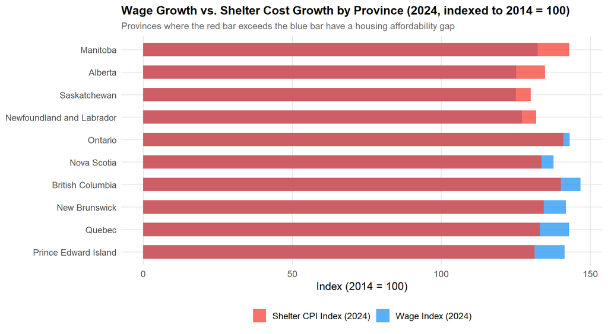

```r
PROVINCES <- c(
  "British Columbia", "Alberta", "Saskatchewan", "Manitoba",
  "Ontario", "Quebec", "New Brunswick", "Nova Scotia",
  "Prince Edward Island", "Newfoundland and Labrador"
)

prov_2024 <- wages_vs_cpi %>%
  filter(year == 2024, geo %in% PROVINCES) %>%
  mutate(
    affordability_gap = shelter_index - wage_index,
    geo = fct_reorder(geo, affordability_gap)   # order bars by gap
  )

# Long format for grouped bars
prov_long <- prov_2024 %>%
  select(geo, wage_index, shelter_index) %>%
  pivot_longer(
    cols      = c(wage_index, shelter_index),
    names_to  = "series",
    values_to = "index_value"
  ) %>%
  mutate(series = recode(series,
    wage_index    = "Wage Index (2024)",
    shelter_index = "Shelter CPI Index (2024)"
  ))

ggplot(prov_long, aes(x = index_value, y = geo, fill = series)) +
  geom_col(position = "identity", alpha = 0.75, width = 0.6) +
  scale_fill_manual(values = c(
    "Wage Index (2024)"          = "#2196F3",
    "Shelter CPI Index (2024)"   = "#F44336"
  )) +
  labs(
    title    = "Wage Growth vs. Shelter Cost Growth by Province (2024, indexed to 2014 = 100)",
    subtitle = "Provinces where the red bar exceeds the blue bar have a housing affordability gap",
    x        = "Index (2014 = 100)",
    y        = NULL,
    fill     = NULL
  ) +
  theme_pulse()
```

```r
prov_2024 %>%
  arrange(desc(affordability_gap)) %>%
  select(Province = geo, `Wage Index` = wage_index,
         `Shelter Index` = shelter_index, `Gap` = affordability_gap) %>%
  mutate(across(where(is.numeric), ~ round(.x, 1)))
```

```
## # A tibble: 10 × 4
##    Province                  `Wage Index` `Shelter Index`   Gap
##    <fct>                            <dbl>           <dbl> <dbl>
##  1 Manitoba                          132.            143   10.6
##  2 Alberta                           125.            135.   9.7
##  3 Saskatchewan                      125             130.   5
##  4 Newfoundland and Labrador         127.            132.   4.8
##  5 Ontario                           143.            141.  -2.1
##  6 Nova Scotia                       138.            134.  -4.1
##  7 British Columbia                  147.            140.  -6.6
##  8 New Brunswick                     142.            134.  -7.4
##  9 Quebec                            143             133.  -9.9
## 10 Prince Edward Island              141.            131. -10.1
```

## 4. Chart 3 — Employment by Industry Over Time

> Which sectors have grown or shrunk since 2014?

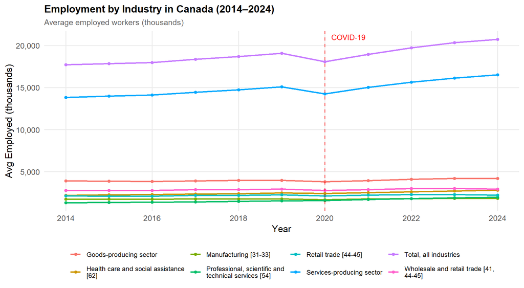

```r
# Top 8 industries by 2019 (pre-COVID) employment
top_industries <- emp_annual %>%
  filter(year == 2019) %>%
  slice_max(avg_employed_thousands, n = 8) %>%
  pull(industry)

emp_top <- emp_annual %>%
  filter(industry %in% top_industries) %>%
  mutate(industry = stringr::str_wrap(industry, width = 35))   # wrap long labels

ggplot(emp_top, aes(x = year, y = avg_employed_thousands, colour = industry)) +
  geom_line(linewidth = 1) +
  geom_point(size = 1.5) +
  geom_vline(xintercept = 2020, linetype = "dashed",
             colour = "red", alpha = 0.6) +
  annotate("text", x = 2020.15, y = Inf, label = "COVID-19",
           hjust = 0, vjust = 1.5, colour = "red", size = 3.5) +
  scale_x_continuous(breaks = seq(2014, 2024, 2)) +
  scale_y_continuous(labels = comma) +
  labs(
    title    = "Employment by Industry in Canada (2014–2024)",
    subtitle = "Average employed workers (thousands)",
    x        = "Year",
    y        = "Avg Employed (thousands)",
    colour   = NULL
  ) +
  theme_pulse() +
  theme(legend.text = element_text(size = 9))
```

```r
pre_covid  <- emp_annual %>% filter(year == 2019) %>%
  select(industry, emp_2019 = avg_employed_thousands)

post_covid <- emp_annual %>% filter(year == 2024) %>%
  select(industry, emp_2024 = avg_employed_thousands)

recovery <- pre_covid %>%
  inner_join(post_covid, by = "industry") %>%
  mutate(pct_change = (emp_2024 - emp_2019) / emp_2019 * 100) %>%
  arrange(desc(pct_change))

cat("Employment change 2019 → 2024 (%):\n")
```

```
## Employment change 2019 → 2024 (%):
```

```r
recovery %>%
  mutate(pct_change = round(pct_change, 1)) %>%
  select(Industry = industry, `Change (%)` = pct_change) %>%
  print(n = Inf)
```

```
## # A tibble: 28 × 2
##    Industry                                                         `Change (%)`
##    <chr>                                                                   <dbl>
##  1 Professional, scientific and technical services [54]                     27
##  2 Public administration [91]                                               24.8
##  3 Finance and insurance [52]                                               19.3
##  4 Educational services [61]                                                18.4
##  5 Finance, insurance, real estate, rental and leasing [52, 53]             15.6
##  6 Utilities [22]                                                           14.7
##  7 Health care and social assistance [62]                                   13.9
##  8 Mining, quarrying, and oil and gas extraction [21, 2100]                 10.6
##  9 Services-producing sector                                                 9.6
## 10 Construction [23]                                                         9.2
## 11 Total, all industries                                                     8.7
## 12 Information, culture and recreation [51, 71]                              8.3
```

[output cut: 16 more lines]

## 5. Summary of Findings

- **Finding 1:** Nationally, wage growth marginally outpaced shelter cost growth by 2024 — the wage index reached 139.8 vs. a shelter index of 137.9 (both indexed to 2014 = 100). However, this national average masks significant regional disparities.
- **Finding 2:** The provinces with the largest housing affordability gaps (shelter CPI rising faster than wages) were **Manitoba** (+10.6 index points), **Alberta** (+9.7), and **Saskatchewan** (+5.0). By contrast, British Columbia, Quebec, and Prince Edward Island saw wage growth outpace shelter costs — suggesting stronger labour market gains relative to local housing inflation.
- **Finding 3:** The industries with the strongest employment growth from 2019 to 2024 were **Professional, Scientific and Technical Services** (+27.0%), **Public Administration** (+24.8%), and **Finance and Insurance** (+19.3%) — reflecting a structural shift toward knowledge-economy and government jobs post-pandemic.
- **Finding 4:** Industries still below 2019 employment levels by 2024 include **Agriculture** (-21.1%), **Business, Building and Other Support Services** (-7.2%), and **Accommodation and Food Services** (-6.5%) — sectors hardest hit by COVID-19 that have not fully recovered.
- **Overall:** While Canada’s national wage growth kept pace with shelter costs on average, the regional picture is uneven. Prairie provinces face the steepest affordability pressures, and lower-wage service sectors have yet to recover pre-pandemic employment levels — compounding financial strain for households already facing elevated housing costs.